# R Help Sheet for the Poster Project

Math 260 Applied Statistics

This sheet collects the R steps you are most likely to need while building your poster. Every box of code can be **copied with the button in its top-right corner** and pasted into your own Quarto file.

The examples use two datasets from `math260projdata`, `coasters` and `happiness`. **Swap in the names of your own dataset and variables** wherever you see them. Names, spelling and capitalization must match your data exactly.

The recipes build on each other in order. If an example uses `coasters2`, it was created in Section 3.

# 1. Look at your data first

Before you filter or recode anything, check what is actually there.

```r
head(coasters, n = 3)                # first few rows
```

```
           name          park material   seating    status speed height length
1      Goudurix  Parc Asterix    Steel  Sit Down Operating    75     37    950
2 Dream catcher Bobbejaanland    Steel Suspended Operating    45     25    600
3    Alucinakis  Terra Mítica    Steel  Sit Down Operating    30      8    250
  inversions
1          7
2          0
3          0
```

```r
names(coasters)                      # variable names
```

```
[1] "name"       "park"       "material"   "seating"    "status"
[6] "speed"      "height"     "length"     "inversions"
```

```r
tally(~ material, data = coasters)   # labels of a categorical variable
```

```
material
Hybrid  Steel Wooden
    18   1043    146
```

```r
favstats(~ speed, data = coasters)   # a quantitative variable
```

```
 min Q1 median Q3 max     mean       sd    n missing
   7 50     75 89 240 72.38691 27.50083 1207       0
```

**TipWhy check labels?**

Filtering and recoding only work if you type each category **exactly** as it appears (`"Wooden"`, not `"wooden"`). Use `tally()` to see the exact spelling.

# 2. Filter cases

Filtering keeps only the rows you want. **Always save the result under a new name** (like `steel` below) so your original data stay intact.

**Keep one group**

```r
steel <- coasters |> filter(material == "Steel")
```

**Keep two (or more) groups.** Use `%in%` with a list of labels. Add `droplevels()` so the unused category does not linger in tables and graphs.

```r
two_types <- coasters |>
  filter(material %in% c("Steel", "Wooden")) |>
  droplevels()
```

**Keep cases that meet a numerical condition.** A comma between conditions means “and”.

```r
tall_fast <- coasters |> filter(height > 40, speed >= 100)
```

**Look for outliers, then remove one only if you have a reason.**

```r
# The five fastest coasters
coasters |> arrange(desc(speed)) |> select(name, speed, height) |> head(n = 5)
```

```
                 name speed height
1       Formula Rossa   240     52
2           Kingda Ka   206    139
3 Top Thrill Dragster   192    128
4           Red Force   185    112
5          Do-Dodonpa   172     52
```

```r
# Drop only the 240 km/h coaster, then count the cases before and after
no_outlier <- coasters |> filter(speed < 220)
nrow(coasters)
```

```
[1] 1207
```

```r
nrow(no_outlier)
```

```
[1] 1206
```

**Drop cases with a missing value** for one variable

```r
happy_known <- happiness |> filter(!is.na(continent))
```

**TipPoster tip**

Be sure to say on your poster the sample size for the final sample after any removed cases.

# 3. Recode variables

Recoding creates a **new column** with `mutate()`. Most of the course methods compare two groups, so these recipes turn a variable into a two-category variable.

**Categorical to binary: one category versus all the others**

```r
coasters2 <- coasters |>
  mutate(wooden = ifelse(material == "Wooden", "Wooden", "Not wooden"))
```

**Quantitative to binary: split at a cutoff you can justify**

```r
coasters2 <- coasters2 |>
  mutate(fast = ifelse(speed >= 100, "Fast", "Not fast"))
```

**Collapse several categories into two** (this one uses `happiness`)

```r
happiness2 <- happiness |>
  mutate(region2 = ifelse(continent %in% c("Europe", "Americas"), "Europe/Americas", "Other"))
```

**Quantitative to several ordered groups** with `cut()`

```r
coasters2 <- coasters2 |>
  mutate(height_group = cut(height, breaks = c(0, 20, 40, Inf),
                            labels = c("Low (up to 20 m)", "Medium (20 to 40 m)", "Tall (over 40 m)")))
```

**Choose which group comes first.** The first level listed comes first in tables and graphs.

```r
coasters2 <- coasters2 |>
  mutate(wooden = factor(wooden, levels = c("Wooden", "Not wooden")))
```

**Always check that the recode did what you intended**

```r
tally(wooden ~ material, data = coasters2)
```

```
            material
wooden       Hybrid Steel Wooden
  Wooden          0     0    146
  Not wooden     18  1043      0
```

```r
tally(fast ~ height_group, data = coasters2)
```

```
          height_group
fast       Low (up to 20 m) Medium (20 to 40 m) Tall (over 40 m)
  Fast                    3                  25              163
  Not fast              468                 504               44
```

**TipKeep your data steps together**

Put all of your filtering and recoding in one chunk near the top of your Quarto file, and give the final dataset one name. Then your whole analysis re-runs correctly every time you render.

# 4. Numerical summaries and tables

**Compare a quantitative variable across two groups**

```r
favstats(speed ~ wooden, data = coasters2)
```

```
      wooden min Q1 median   Q3 max     mean       sd    n missing
1     Wooden  32 75     85 91.5 126 82.61644 16.41331  146       0
2 Not wooden   7 47     72 88.0 240 70.97926 28.41156 1061       0
```

**Difference in group means.** R subtracts the first group’s mean from the second’s, so this is the mean for “Not wooden” minus the mean for “Wooden”. Reverse the order of the levels in Section 3 if you would rather report it the other way.

```r
diffmean(speed ~ wooden, data = coasters2)
```

```
 diffmean
-11.63717
```

**Compare proportions.** The first table gives conditional proportions for each group. The second gives one proportion.

```r
tally(fast ~ wooden, data = coasters2, format = "proportion")
```

```
          wooden
fast          Wooden Not wooden
  Fast     0.1369863  0.1611687
  Not fast 0.8630137  0.8388313
```

```r
prop(~ fast, data = coasters2, success = "Fast")
```

```
prop_Fast
0.1582436
```

**A clean table for your poster.** Choose only the columns your audience needs and round them. When you render your Quarto file, you can copy this table from the HTML page and paste it into PowerPoint.

```r
favstats(speed ~ wooden, data = coasters2) |>
  select(wooden, n, mean, sd) |>
  knitr::kable(digits = 1)
```

| wooden | n | mean | sd |
| --- | --- | --- | --- |
| Wooden | 146 | 82.6 | 16.4 |
| Not wooden | 1061 | 71.0 | 28.4 |

# 5. Graphs for your poster

Pick the tab that matches your variables. Each recipe already includes labels (see the last tab for what each label does).

**Compare groups: histograms**

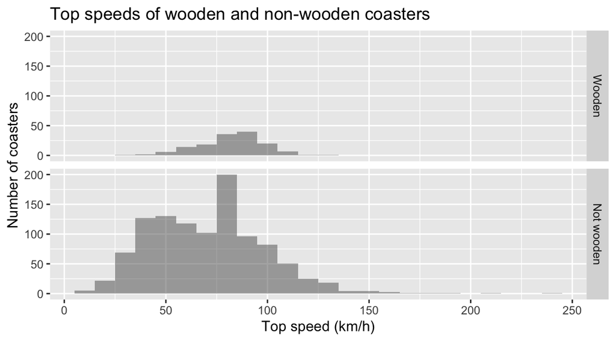

```r
gf_histogram(~ speed | wooden ~ ., data = coasters2, binwidth = 10) |>
  gf_labs(title = "Top speeds of wooden and non-wooden coasters",
          x = "Top speed (km/h)", y = "Number of coasters")
```

**Compare groups: boxplots**

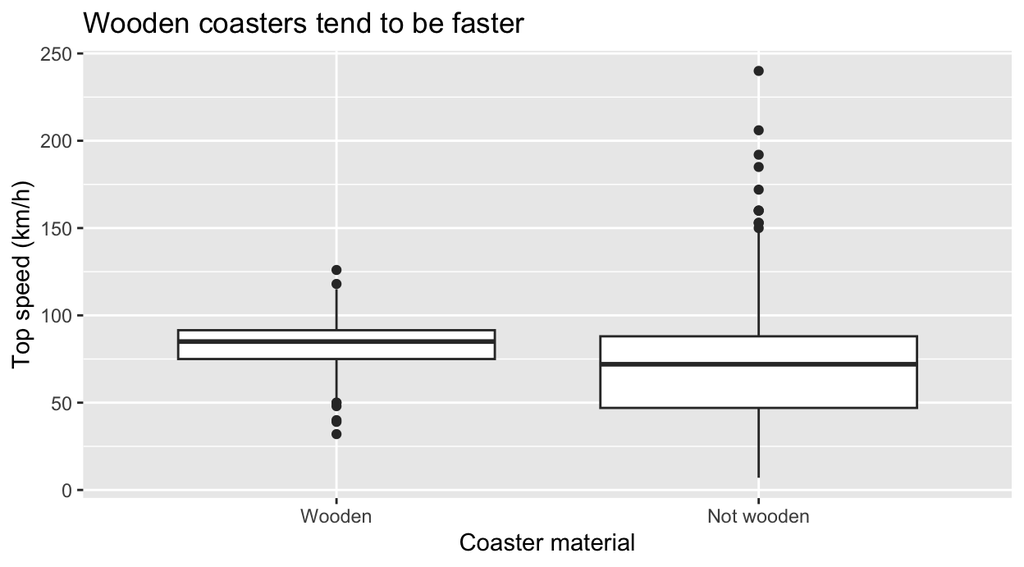

```r
gf_boxplot(speed ~ wooden, data = coasters2) |>
  gf_labs(title = "Wooden coasters tend to be faster",
          x = "Coaster material", y = "Top speed (km/h)")
```

**Two quantitative variables**

One overall line:

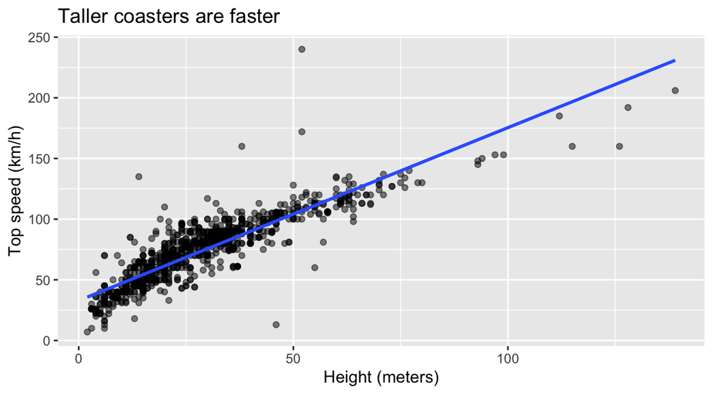

```r
gf_point(speed ~ height, data = coasters2, alpha = 0.5) |>
  gf_smooth(method = "lm") |>
  gf_labs(title = "Taller coasters are faster",
          x = "Height (meters)", y = "Top speed (km/h)")
```

Color the points by group:

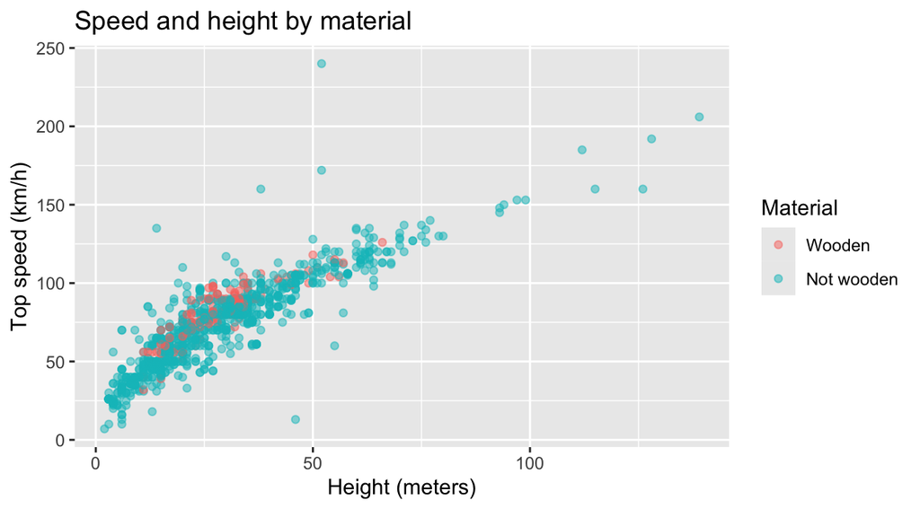

```r
gf_point(speed ~ height, data = coasters2, color = ~ wooden, alpha = 0.5) |>
  gf_labs(title = "Speed and height by material",
          x = "Height (meters)", y = "Top speed (km/h)", color = "Material")
```

**Categorical variables**

One variable:

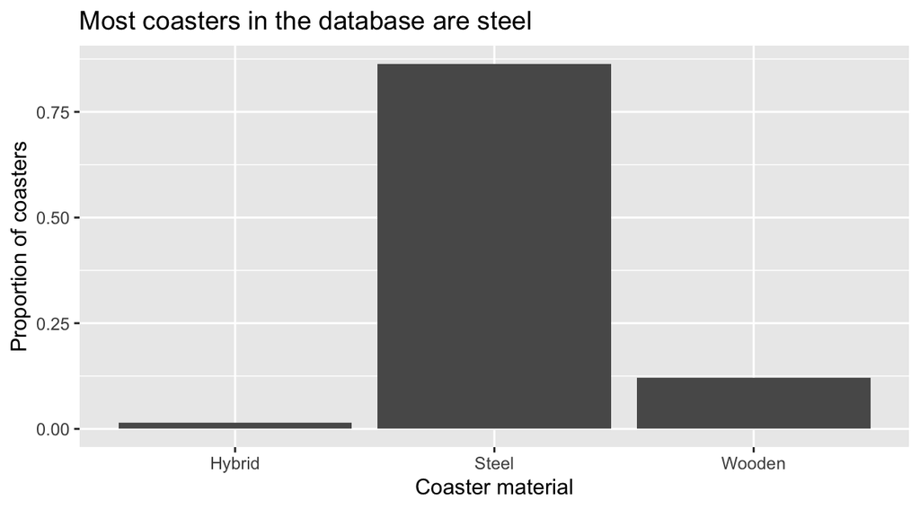

```r
gf_props(~ material, data = coasters2) |>
  gf_labs(title = "Most coasters in the database are steel",
          x = "Coaster material", y = "Proportion of coasters")
```

Compare groups with stacked bars:

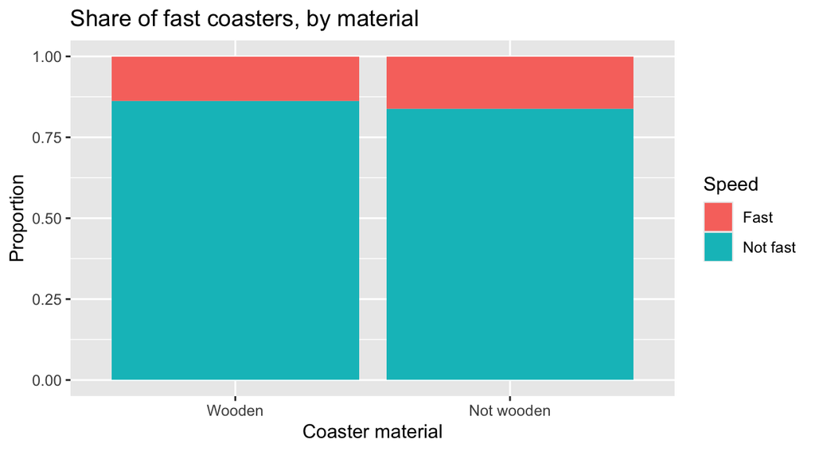

```r
gf_props(~ wooden, fill = ~ fast, data = coasters2, position = "fill") |>
  gf_labs(title = "Share of fast coasters, by material",
          x = "Coaster material", y = "Proportion", fill = "Speed")
```

If the category names are long, flip the bars with `gf_refine(coord_flip())` added at the end.

**Labels, size and color**

`gf_labs()` can set any of these (use only the ones you need):

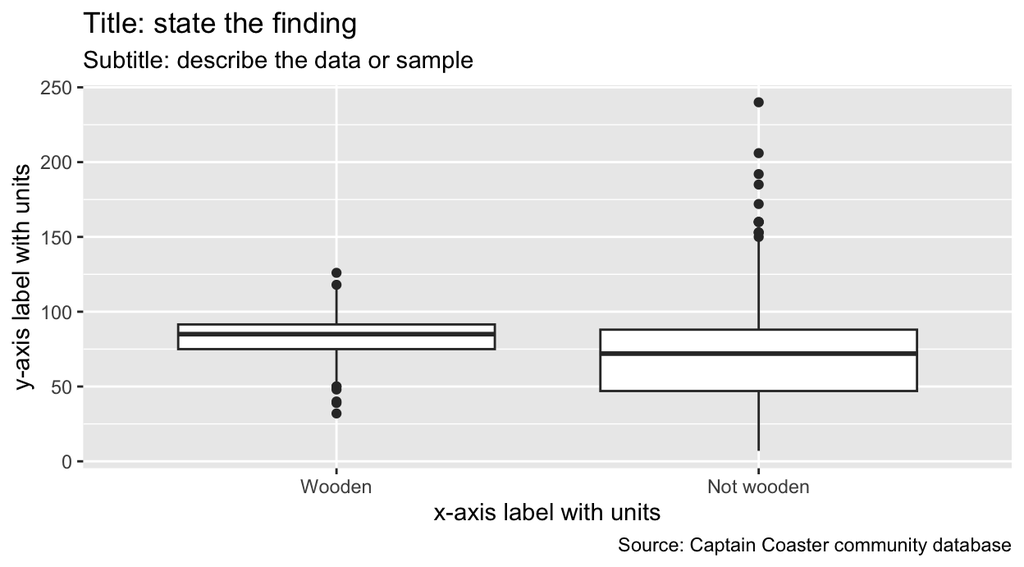

```r
gf_boxplot(speed ~ wooden, data = coasters2) |>
  gf_labs(title = "Title: state the finding",
          subtitle = "Subtitle: describe the data or sample",
          x = "x-axis label with units",
          y = "y-axis label with units",
          caption = "Source: Captain Coaster community database")
```

**Make text large enough for a poster** by adding `gf_theme()` as the last step:

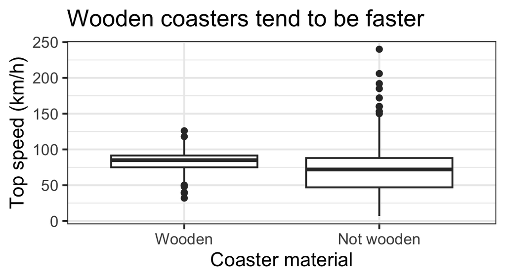

```r
gf_boxplot(speed ~ wooden, data = coasters2) |>
  gf_labs(title = "Wooden coasters tend to be faster",
          x = "Coaster material", y = "Top speed (km/h)") |>
  gf_theme(theme_bw(base_size = 18))
```

**Choose colors.** A `~` before a variable name means “use a different color for each group”. Quotes around a color name mean “use this one color for everything”.

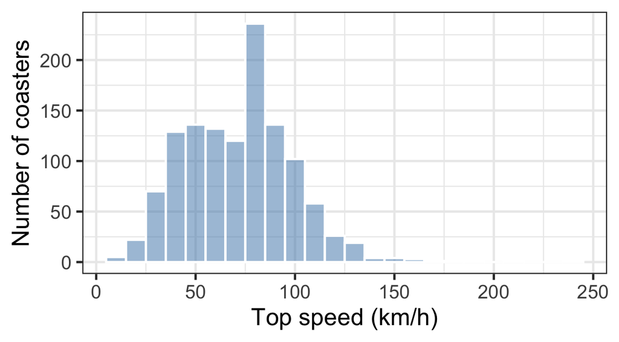

```r
gf_histogram(~ speed, data = coasters2, binwidth = 10, fill = "steelblue", color = "white") |>
  gf_labs(x = "Top speed (km/h)", y = "Number of coasters") |>
  gf_theme(theme_bw(base_size = 18))
```

Type `colors()` at the Console to see the names R knows.

# 6. Save a graph as a PNG for PowerPoint

**Point and click.** Make your graph, then in the **Plots** pane choose **Export → Save as Image**. Pick **PNG**, set the size, and save the file in your project folder. You can also choose **Copy to Clipboard** and paste straight into your poster.

**With code.** Save the graph under a name, then use `ggsave()`. The size is in inches.

```r
speed_plot <- gf_boxplot(speed ~ wooden, data = coasters2) |>
  gf_labs(title = "Wooden coasters tend to be faster",
          x = "Coaster material", y = "Top speed (km/h)") |>
  gf_theme(theme_bw(base_size = 18))

ggsave("speed_boxplot.png", plot = speed_plot, width = 8, height = 5, dpi = 300)
```

The file is saved in your working directory. Type `getwd()` at the Console to see where that is.

**TipCheck the size on your poster**

Text scales with the image. If the text looks too small after you place the image on your poster, save it again with a smaller `width`/`height` or a larger `base_size`. Resizing the picture in PowerPoint does not fix the text size relative to the rest of the poster.

# 7. Save your cleaned data to a file

To use your filtered or recoded data somewhere else, such as StatKey or Excel, write it to a CSV file. Keeping only the columns you need makes the file easier to work with.

```r
two_types |>
  select(name, material, speed) |>
  write.csv("coasters_two_types.csv", row.names = FALSE)
```

# 8. When something goes wrong

| What you see | What it usually means |
| --- | --- |
| `object 'xxx' not found` | A typo, or you did not run the chunk that creates it, or you forgot to save a result with `<-` |
| `could not find function "filter"` | The setup chunk with `library(mosaic)` has not been run |
| Zero rows after `filter()` | A category was spelled differently than in the data. Check with `tally()`. Use `==`, not `=` |
| An empty category in a table or graph | Add `\|> droplevels()` after your `filter()` |
| `unexpected symbol` or `unexpected ','` | A missing or extra comma, quote or parenthesis. A `\|>` goes at the **end** of a line, never the start |
| New column is all `NA` | The old column name or a category label in `ifelse()` is misspelled |